# CSDE 502 Winter 2021, Assignment 10

Nicholas Irons [njirons@uw.edu]

# 1 Exploratory Data Analysis: Add Health Data

As described in the assignment prompt, our goal is to look at sociodemographic predictors of the number of correct answers to the Add Health Knowledge Quiz.

## 1.1 Data processing

We begin by loading in the Add Health Wave 1 Data and calculating the number of correct answers of each participant above the age of 15.

```r
# load Add Health Wave 1 data
dat <- haven::read_dta("http://staff.washington.edu/phurvitz/csde502_winter_2021/data/AHwave1_v1.dta")

metadata <- bind_cols(
    # variable name
    varname = colnames(dat),
    # label
    varlabel = lapply(dat, function(x) attributes(x)$label) %>%
        unlist(),
    # values
    varvalues = lapply(dat, function(x) attributes(x)$labels) %>%
        # names the variable label vector
        lapply(., function(x) names(x)) %>%
        # as character
        as.character() %>%
        # remove the c() construction
        str_remove_all("^c\\(|\\)$")
)

# select knowledge quiz columns
mydat <- dat %>%
    filter(h1kq1a != 7) %>%
    select(
        aid,
        matches("h1kq.*a")
    )

# the correct answers from viewing the metadata
correct <- c(2, 1, 2, 2, 2, 2, 2, 1, 2, 2)

# make a named vector of the answers using the selected column names
names(correct) <- str_subset(string = names(mydat),
                             pattern = "h1kq.*a")

# determine correct answers
answers <- mydat %>%
    # drop the aid column
    select(-aid) %>%
    # run the sweep
    sweep(x = ., MARGIN = 2, STATS = correct, FUN = "==") %>%
    # convert to data frame
    data.frame()

# calculate number of correct answers
answers %<>%
    # calculate the rowSums
    mutate(h1kqNa_sum = rowSums(.)) %>%
    # bring the ID back in
    mutate(aid = mydat$aid) %>%
    # reorder columns
    select(aid, h1kqNa_sum, everything())

# merge with original dataset
answers %<>%
    left_join(dat, by = "aid") %>%
    mutate(
        sex = case_when(
            bio_sex == 1 ~ 'male',
            bio_sex == 2 ~ 'female'
        )
    )
```

# 2 Data exploration

Now we will create a few plots and calculate summary statistics to compare performance on the knowledge quiz across various sociodemographic groups.

## 2.1 Sex

We first look at scores on the knowledge quiz by sex.

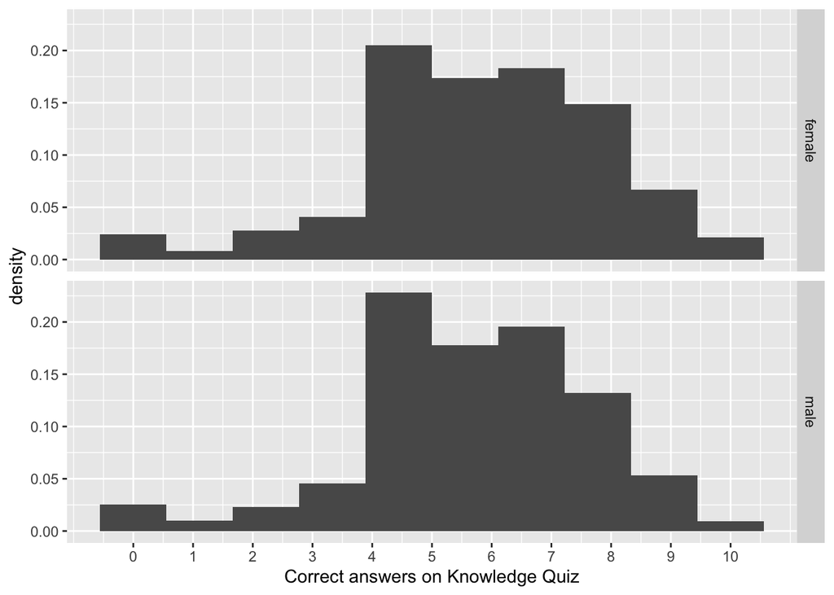

```r
# plot histogram of correct answers by sex
ggplot(data = answers, mapping = aes(x = h1kqNa_sum))+
    geom_histogram(aes(y=..density..), bins=10) +
    facet_grid(sex ~ .) +
    xlab("Correct answers on Knowledge Quiz") +
    scale_x_continuous(breaks=0:10)
```

*Figure 1: Knowledge quiz score histogram by sex.*

```r
answers %>%
  group_by(sex) %>%
  summarize(score_avg = mean(h1kqNa_sum),
            score_median = median(h1kqNa_sum),
            score_sd = sd(h1kqNa_sum),
            sample_size = n()) %>%
  kable() %>%
  kable_styling(full_width = FALSE, position = "left")
```

| sex | score_avg | score_median | score_sd | sample_size |
| --- | --- | --- | --- | --- |
| female | 6.076615 | 6 | 2.117412 | 2245 |
| male | 5.905856 | 6 | 2.044274 | 2220 |

*Table 1: Knowledge quiz score statistics by sex.*

Based on Figure 1 and Table 1 it appears that, on average, women tend to score higher than men on the quiz. Let’s see if this disparity is reflected in the reported confidence in their answers.

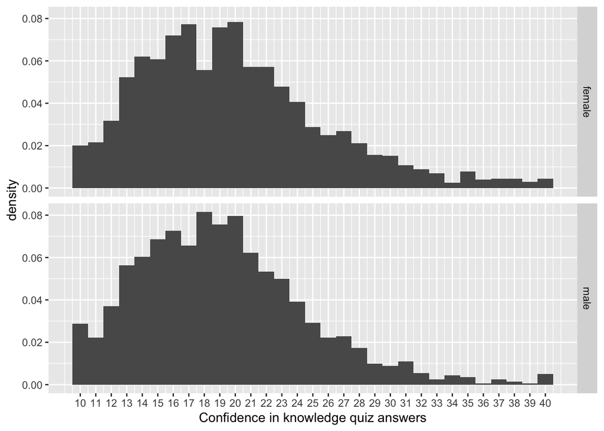

```r
# calculate knowledge quiz confidence score
answers %<>% mutate(
  kqconfidence = case_when(
    h1kq1b > 4 ~ 0, # NA
    h1kq2b > 4 ~ 0,
    h1kq3b > 4 ~ 0,
    h1kq4b > 4 ~ 0,
    h1kq5b > 4 ~ 0,
    h1kq6b > 4 ~ 0,
    h1kq7b > 4 ~ 0,
    h1kq8b > 4 ~ 0,
    h1kq9b > 4 ~ 0,
    h1kq10b > 4 ~ 0,
    TRUE ~ h1kq1b + h1kq2b + h1kq3b + h1kq4b +
      h1kq5b + h1kq6b + h1kq7b + h1kq8b + h1kq9b + h1kq10b
  )
)

# plot histogram of confidence in answers by sex
ggplot(data = answers %>% filter(kqconfidence > 0), mapping = aes(x = kqconfidence))+
    geom_histogram(aes(y=..density..), bins=31) +
    facet_grid(sex ~ .) +
    xlab("Confidence in knowledge quiz answers") +
    scale_x_continuous(breaks=10:40)
```

*Figure 2: Knowledge quiz confidence histogram by sex.*

```r
answers %>%
  group_by(sex) %>%
  summarize(conf_avg = mean(kqconfidence),
            conf_median = median(kqconfidence),
            conf_sd = sd(kqconfidence),
            sample_size = n()) %>%
  kable() %>%
  kable_styling(full_width = FALSE, position = "left")
```

| sex | conf_avg | conf_median | conf_sd | sample_size |
| --- | --- | --- | --- | --- |
| female | 18.07127 | 18 | 8.009258 | 2245 |
| male | 17.43784 | 18 | 7.520152 | 2220 |

*Table 2: Knowledge quiz confidence statistics by sex.*

Based on Figure 2 and Table 2 (and recalling that a lower confidence score implies higher confidence) it appears that, on average, men tend to report higher confidence than women on the knowledge quiz, despite having lower scores on average. Of course, these are just marginal averages, and I have not looked at the joint distribution of quiz score and reported confidence by sex.

## 2.2 Ethnicity/race

### 2.2.1 Hispanic ethnicity

We now look at scores on the knowledge quiz by Hispanic ethnicity status.

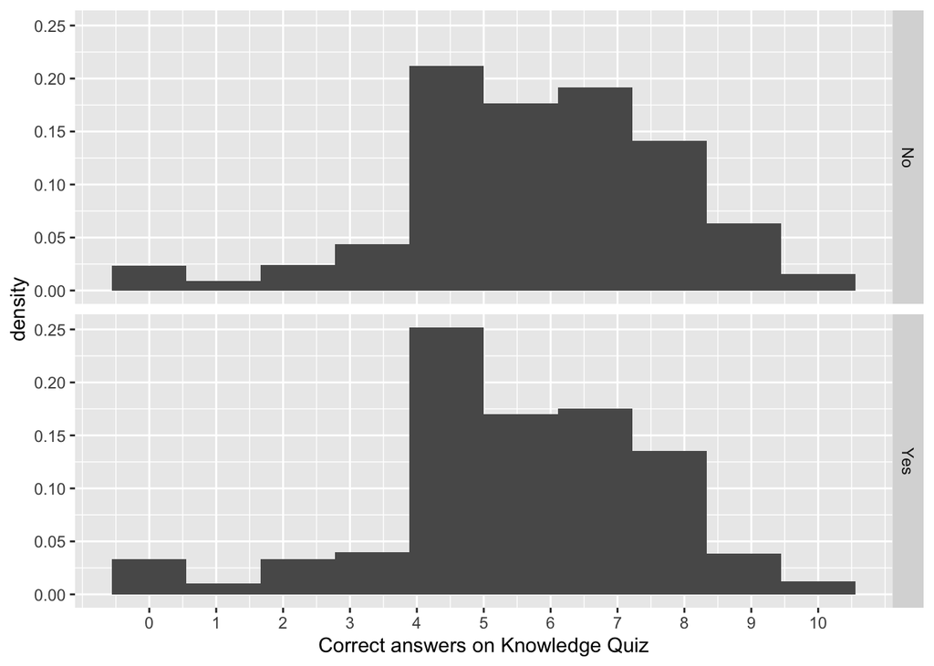

```r
answers %<>%
  # define new hispanic ethnicity status variable
  mutate(hispanic = case_when(
    h1gi4 == 0 ~ "No",
    h1gi4 == 1 ~ "Yes",
    TRUE ~ "NA"
  ))

# plot histogram of correct answers by hispanic ethnicity status
ggplot(data = answers %>% filter(hispanic != "NA"), mapping = aes(x = h1kqNa_sum))+
    geom_histogram(aes(y=..density..), bins=10) +
    facet_grid(hispanic ~ .) +
    xlab("Correct answers on Knowledge Quiz") +
    scale_x_continuous(breaks=0:10)
```

*Figure 3: Knowledge quiz score histogram by hispanic ethnicity status*

```r
answers %>%
  filter(hispanic != "NA") %>%
  # group by hispanic ethnicity status
  group_by(hispanic) %>%
  summarize(score_avg = mean(h1kqNa_sum),
            score_median = median(h1kqNa_sum),
            score_sd = sd(h1kqNa_sum),
            sample_size = n()) %>%
  kable() %>%
  kable_styling(full_width = FALSE, position = "left")
```

| hispanic | score_avg | score_median | score_sd | sample_size |
| --- | --- | --- | --- | --- |
| No | 6.025634 | 6 | 2.073198 | 3940 |
| Yes | 5.762548 | 6 | 2.110943 | 518 |

*Table 3: Knowledge quiz score statistics by Hispanic ethnicity status.*

Based on Figure 3 and Table 3, it appears that, on average, non-Hispanics tend to score higher than Hispanics on the quiz.

### 2.2.2 Race

We now look at scores on the knowledge quiz by race.

```r
# define single race variable
answers %<>%
  mutate(
    single_race = case_when(
      h1gi8 == 1 ~ "white",
      h1gi8 == 2 ~ "black",
      h1gi8 == 3 ~ "native american",
      h1gi8 == 4 ~ "asian",
      h1gi8 == 5 ~ "other",
      h1gi8 == 7 ~ case_when( # single race marked
        h1gi6a == 1 ~ "white", # white
        h1gi6b == 1 ~ "black", # black/african american
        h1gi6c == 1 ~ "native american", # american indian/native american
        h1gi6d == 1 ~ "asian", # asian/pacific islander
        h1gi6e == 1 ~ "other", # other
        TRUE ~ "NA"
      ),
      TRUE ~ "NA"
    )
  )

answers %>%
  filter(single_race != "NA") %>%
  # group by race
  group_by(single_race) %>%
  summarize(score_avg = mean(h1kqNa_sum),
            score_median = median(h1kqNa_sum),
            score_sd = sd(h1kqNa_sum),
            sample_size = n()) %>%
  arrange(desc(score_avg)) %>%
  kable() %>%
  kable_styling(full_width = FALSE, position = "left")
```

| single_race | score_avg | score_median | score_sd | sample_size |
| --- | --- | --- | --- | --- |
| native american | 6.193548 | 6 | 1.809254 | 62 |
| white | 6.075518 | 6 | 2.057737 | 2847 |
| black | 5.852055 | 6 | 2.138280 | 1095 |
| asian | 5.818750 | 6 | 2.058490 | 160 |
| other | 5.804271 | 6 | 2.104616 | 281 |

*Table 4: Knowledge quiz score statistics by race.*

## 2.3 Birth year cohort

We now look at scores on the knowledge quiz by birth year cohort.

```r
answers %>%
  mutate(birth_year = h1gi1y) %>%
  # group by birth year
  group_by(birth_year) %>%
  summarize(score_avg = mean(h1kqNa_sum),
            score_median = median(h1kqNa_sum),
            score_sd = sd(h1kqNa_sum),
            sample_size = n()) %>%
  kable() %>%
  kable_styling(full_width = FALSE, position = "left")
```

| birth_year | score_avg | score_median | score_sd | sample_size |
| --- | --- | --- | --- | --- |
| 74 | 2.666667 | 3 | 2.743977 | 18 |
| 75 | 4.837209 | 6 | 3.038877 | 43 |
| 76 | 6.172237 | 7 | 1.982826 | 389 |
| 77 | 6.363795 | 7 | 1.934902 | 1149 |
| 78 | 6.129170 | 6 | 2.020760 | 1169 |
| 79 | 5.791738 | 6 | 2.101146 | 1162 |
| 80 | 5.400000 | 6 | 2.141266 | 535 |

*Table 5: Knowledge quiz score statistics by birth year cohort*

Based on Table 5, there appears to be variation in Knowedlege quiz scores across birth cohorts. Notably, we see rather large average quiz score increases as birth year (which we can think of as an *imperfect* proxy for age at time of interview) increases from 1974 to 1977. Average quiz score then declines some as birth year increases from 1977 to 1980.

Considering that the Wave 1 interviews took place in 1994-1995, respondents born in 1974-1975 would be between 18 and 21 years old at the time of interview. Lower performance on the knowledge quiz may then be explained by some of these older students having learning difficulties.

On the other hand, respondents in the younger birth cohorts might be expected to perform worse on the knowledge quiz than older students because they have not received as much sex education at the time of interview.

# 3 Research Question and Hypothesis

Considering our observations about knowledge quiz score differences between birth year cohorts, one interesting research question (which we may not be able to answer with the Add Health data alone) is: “Does comprehensive sex education significantly increase students’ knowledge about contraception?” Based on my initial findings, I would hypothesize that the answer is “yes.”

Rendered at `2022-03-17 19:04:00`

## 3.1 Source code

File is at /Users/njirons/Documents/GitHub/csde502_winter_2022_njirons/csde502_2022_assignment_10.Rmd.

### 3.1.1 R code used in this document

```r
knitr::opts_chunk$set(echo = TRUE)

pacman::p_load(
    tidyverse,
    magrittr,
    knitr,
    kableExtra,
    haven,
    pdftools,
    curl,
    ggplot2,
    captioner
)

figure_nums <- captioner(prefix = "Figure")
table_nums <- captioner(prefix = "Table")

# path to this file name
if (!interactive()) {
    fnamepath <- knitr::current_input(dir = TRUE)
} else {
    fnamepath <- ""
}
# load Add Health Wave 1 data
dat <- haven::read_dta("http://staff.washington.edu/phurvitz/csde502_winter_2021/data/AHwave1_v1.dta")

metadata <- bind_cols(
    # variable name
    varname = colnames(dat),
    # label
    varlabel = lapply(dat, function(x) attributes(x)$label) %>%
        unlist(),
    # values
    varvalues = lapply(dat, function(x) attributes(x)$labels) %>%
        # names the variable label vector
        lapply(., function(x) names(x)) %>%
        # as character
        as.character() %>%
        # remove the c() construction
        str_remove_all("^c\\(|\\)$")
)

# select knowledge quiz columns
mydat <- dat %>%
    filter(h1kq1a != 7) %>%
    select(
        aid,
        matches("h1kq.*a")
    )

# the correct answers from viewing the metadata
correct <- c(2, 1, 2, 2, 2, 2, 2, 1, 2, 2)

# make a named vector of the answers using the selected column names
names(correct) <- str_subset(string = names(mydat),
                             pattern = "h1kq.*a")

# determine correct answers
answers <- mydat %>%
    # drop the aid column
    select(-aid) %>%
    # run the sweep
    sweep(x = ., MARGIN = 2, STATS = correct, FUN = "==") %>%
    # convert to data frame
    data.frame()

# calculate number of correct answers
answers %<>%
    # calculate the rowSums
    mutate(h1kqNa_sum = rowSums(.)) %>%
    # bring the ID back in
    mutate(aid = mydat$aid) %>%
    # reorder columns
    select(aid, h1kqNa_sum, everything())

# merge with original dataset
answers %<>%
    left_join(dat, by = "aid") %>%
    mutate(
        sex = case_when(
            bio_sex == 1 ~ 'male',
            bio_sex == 2 ~ 'female'
        )
    )
# plot histogram of correct answers by sex
ggplot(data = answers, mapping = aes(x = h1kqNa_sum))+
    geom_histogram(aes(y=..density..), bins=10) +
    facet_grid(sex ~ .) +
    xlab("Correct answers on Knowledge Quiz") +
    scale_x_continuous(breaks=0:10)
answers %>%
  group_by(sex) %>%
  summarize(score_avg = mean(h1kqNa_sum),
            score_median = median(h1kqNa_sum),
            score_sd = sd(h1kqNa_sum),
            sample_size = n()) %>%
  kable() %>%
  kable_styling(full_width = FALSE, position = "left")
# calculate knowledge quiz confidence score
answers %<>% mutate(
  kqconfidence = case_when(
    h1kq1b > 4 ~ 0, # NA
    h1kq2b > 4 ~ 0,
    h1kq3b > 4 ~ 0,
    h1kq4b > 4 ~ 0,
    h1kq5b > 4 ~ 0,
    h1kq6b > 4 ~ 0,
    h1kq7b > 4 ~ 0,
    h1kq8b > 4 ~ 0,
    h1kq9b > 4 ~ 0,
    h1kq10b > 4 ~ 0,
    TRUE ~ h1kq1b + h1kq2b + h1kq3b + h1kq4b +
      h1kq5b + h1kq6b + h1kq7b + h1kq8b + h1kq9b + h1kq10b
  )
)

# plot histogram of confidence in answers by sex
ggplot(data = answers %>% filter(kqconfidence > 0), mapping = aes(x = kqconfidence))+
    geom_histogram(aes(y=..density..), bins=31) +
    facet_grid(sex ~ .) +
    xlab("Confidence in knowledge quiz answers") +
    scale_x_continuous(breaks=10:40)
answers %>%
  group_by(sex) %>%
  summarize(conf_avg = mean(kqconfidence),
            conf_median = median(kqconfidence),
            conf_sd = sd(kqconfidence),
            sample_size = n()) %>%
  kable() %>%
  kable_styling(full_width = FALSE, position = "left")
answers %<>%
  # define new hispanic ethnicity status variable
  mutate(hispanic = case_when(
    h1gi4 == 0 ~ "No",
    h1gi4 == 1 ~ "Yes",
    TRUE ~ "NA"
  ))

# plot histogram of correct answers by hispanic ethnicity status
ggplot(data = answers %>% filter(hispanic != "NA"), mapping = aes(x = h1kqNa_sum))+
    geom_histogram(aes(y=..density..), bins=10) +
    facet_grid(hispanic ~ .) +
    xlab("Correct answers on Knowledge Quiz") +
    scale_x_continuous(breaks=0:10)
answers %>%
  filter(hispanic != "NA") %>%
  # group by hispanic ethnicity status
  group_by(hispanic) %>%
  summarize(score_avg = mean(h1kqNa_sum),
            score_median = median(h1kqNa_sum),
            score_sd = sd(h1kqNa_sum),
            sample_size = n()) %>%
  kable() %>%
  kable_styling(full_width = FALSE, position = "left")
# define single race variable
answers %<>%
  mutate(
    single_race = case_when(
      h1gi8 == 1 ~ "white",
      h1gi8 == 2 ~ "black",
      h1gi8 == 3 ~ "native american",
      h1gi8 == 4 ~ "asian",
      h1gi8 == 5 ~ "other",
      h1gi8 == 7 ~ case_when( # single race marked
        h1gi6a == 1 ~ "white", # white
        h1gi6b == 1 ~ "black", # black/african american
        h1gi6c == 1 ~ "native american", # american indian/native american
        h1gi6d == 1 ~ "asian", # asian/pacific islander
        h1gi6e == 1 ~ "other", # other
        TRUE ~ "NA"
      ),
      TRUE ~ "NA"
    )
  )

answers %>%
  filter(single_race != "NA") %>%
  # group by race
  group_by(single_race) %>%
  summarize(score_avg = mean(h1kqNa_sum),
            score_median = median(h1kqNa_sum),
            score_sd = sd(h1kqNa_sum),
            sample_size = n()) %>%
  arrange(desc(score_avg)) %>%
  kable() %>%
  kable_styling(full_width = FALSE, position = "left")
answers %>%
  mutate(birth_year = h1gi1y) %>%
  # group by birth year
  group_by(birth_year) %>%
  summarize(score_avg = mean(h1kqNa_sum),
            score_median = median(h1kqNa_sum),
            score_sd = sd(h1kqNa_sum),
            sample_size = n()) %>%
  kable() %>%
  kable_styling(full_width = FALSE, position = "left")
cat(readLines(fnamepath), sep = '\n')
```

### 3.1.2 Complete Rmd code

```r
cat(readLines(fnamepath), sep = '\n')
```

````
---
title: "CSDE 502 Winter 2021, Assignment 10"
author: "Nicholas Irons [njirons@uw.edu]"
output:
    bookdown::html_document2:
        number_sections: true
        self_contained: true
        code_folding: hide
        toc: true
        toc_float:
            collapsed: true
            smooth_scroll: false
    pdf_document:
        number_sections: true
        toc: true
        fig_cap: yes
        keep_tex: yes
urlcolor: blue
---

```{r setup, include=FALSE}
knitr::opts_chunk$set(echo = TRUE)

pacman::p_load(
    tidyverse,
    magrittr,
    knitr,
    kableExtra,
    haven,
    pdftools,
    curl,
    ggplot2,
    captioner
)

figure_nums <- captioner(prefix = "Figure")
table_nums <- captioner(prefix = "Table")

# path to this file name
if (!interactive()) {
````

[output cut: 269 more lines]

````

<hr>
Rendered at <tt>`r Sys.time()`</tt>

## Source code
File is at `r fnamepath`.

### R code used in this document
```{r ref.label=knitr::all_labels(), echo=TRUE, eval=FALSE}
```

### Complete Rmd code
```{r comment=''}
cat(readLines(fnamepath), sep = '\n')
```
````